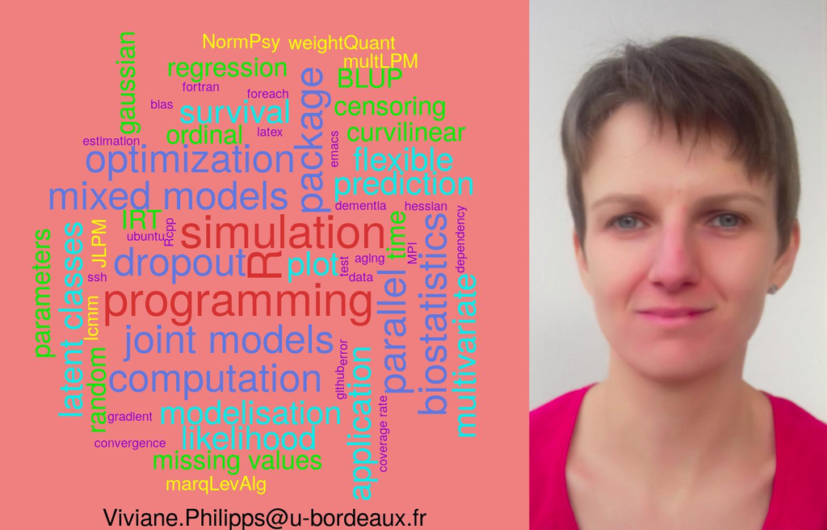

# Profile

I am a statistican in the biostatistics team of the Bordeaux Population Health Center. I take part in the development of new statistical methods for analyzing longitudinal data. I mainly use mixed models, latent class models and joint shared random effects models within a maximum likelihood framework, and my applications focus on aging.

Most of my work is about :

- implementing the statistical methods developped in the team in user friendly R packages
- carrying out simulation studies to compare usual or/and innovative methods in biostatistics
- analyzing real data in aging, in terms of cognitive decline or dependency
- providing methodological support and programming assistance to the members of the team
- parallelization of algorithms
- programming in R, Fortran and C

# Brief resume

Since 2024 : Statistician, Permanent position (Ingénieure d’étude, titulaire INSERM), Bordeaux Population Health center

2012 - 2024 : Statistician, Non-permanent position (Ingénieure d’étude contractuelle), Bordeaux Population Health center.

2012 : 5 months internship in biostatistics, Bordeaux Population Health center

2011 : 2 months internship in biostatistics, IGBMC, Illkirch-Graffenstaden

2010 - 2012 : Master’s degree in statistics, Strasbourg University, France

2007 - 2010 : Bachelor’s degree in mathematics, Strasbourg University, France